# Data Analysis and Visualization of Drug Overdose in USA

## Do overall discharge decrease with severity level?

The goal of this question is to determine whether overall discharge has an impact on severity level. I predict that a higher severity level (where 1 represents minor severity of illness and 4 represents extreme severity of illness) will result in lower overall discharges due to the high amount of time needed for treatment. As such, I created a bar graph of overall discharges (y-axis) by severity level (x-axis).

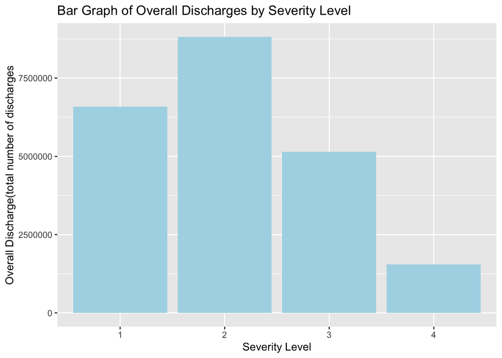

## What trends do we notice in discharges and mean charges/cost?

### Scatter Plot of Mount Sinai Hospital Discharge vs Mean Charge

*Display discharge, mean charge(USD), and severity level(where 1 represents minor severity of illness and 4 represents extreme severity of illness)*

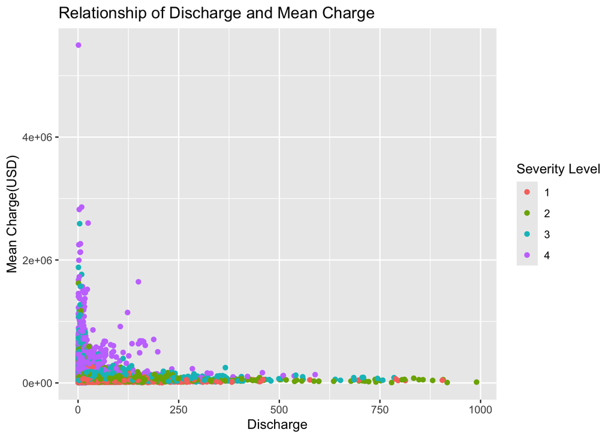